# Chapter 7: Multivariate Analysis

#### Mass Spectroscopy Data Analysis

- This data requires careful preprocessing to obtain desired matrix w/ relevant features(in columns)
  - Raw mass spectroscopy readings -> extract peaks of relevant figures then align across multiple samples & estimate peak heights
- Suggests Bioconductor xcms package
- ex) load matrix of data from mat1xcms.RData file

```r
load(here("BookStuff", "data", "mat1xcms.RData"))
dim(mat1)
```

```
[1] 399  12
```

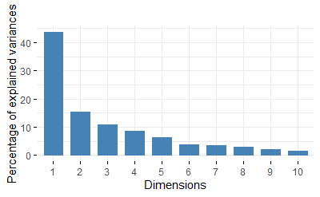

```r
pcamat1 = dudi.pca(t(mat1), scannf = FALSE, nf = 3)
fviz_eig(pcamat1, geom = "bar", bar_width = 0.7) + ggtitle("")
```

```r
dfmat1 = cbind(pcamat1$li, tibble(
    label = rownames(pcamat1$li),
    number = substr(label, 3, 4),
    type = factor(substr(label, 1, 2))))
```

> Screeplot showing the eigenvalues for the mice data.

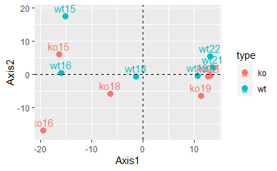

```r
pcsplot = ggplot(dfmat1,
  aes(x=Axis1, y=Axis2, label=label, group=number, colour=type)) +
 geom_text(size = 4, vjust = -0.5)+ geom_point(size = 3)+ylim(c(-18,19))
pcsplot + geom_hline(yintercept = 0, linetype = 2) +
  geom_vline(xintercept = 0, linetype = 2)
```

> The first principal plane for the mat1 data. It explains 59% of the variance.
- 17. Looking at the above PCA plot, do the samples seem to be randomly placed on the plane? Notice any structure explained by the labels?

> The answer becomes (even more) evident if you make this plot. Knockouts are always below their paired wildtype sample. We will revisit this example when we look at supervised multivariate methods in our next chapter.

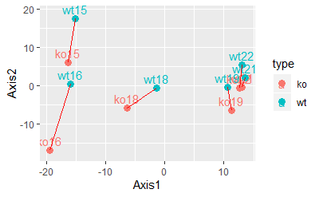

```r
pcsplot + geom_line(colour = "red")
```

#### Biplots and scaling

- Previous example, #variables measured was to large to allow useful concurrent plotting of both variables+samples
- This example, plot PCA biplot of data where chemical measurements made on different wines (also has a categorical wine.class variable)
  - First look at 2d correlations + heatmap of variables

```r
load(here("BookStuff", "data", "wine.RData"))
load(here("BookStuff", "data", "wineClass.RData"))
wine[1:2, 1:7]
```

|  | Alcohol | MalicAcid | Ash | AlcAsh | Mg | Phenols | Flav |
| --- | --- | --- | --- | --- | --- | --- | --- |
| 1 | 14.23 | 1.71 | 2.43 | 15.6 | 127 | 2.80 | 3.06 |
| 2 | 13.20 | 1.78 | 2.14 | 11.2 | 100 | 2.65 | 2.76 |

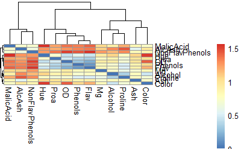

```r
pheatmap(1 - cor(wine), treeheight_row = 0.2)
```

```r
winePCAd = dudi.pca(wine, scannf=FALSE)
```

> The difference between 1 and the correlation can be used as a distance between variables and is used to make a heatmap of the associations between the variables.

```r
table(wine.class)
```

```
wine.class
    barolo grignolino    barbera
        59         71         48
```

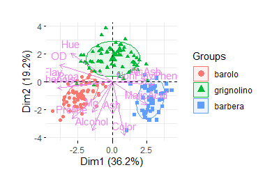

```r
fviz_pca_biplot(winePCAd, geom = "point", habillage = wine.class,
   col.var = "violet", addEllipses = TRUE, ellipse.level = 0.69) +
   ggtitle("") + coord_fixed()
```

> PCA biplot including ellipses for the three types of wine: barolo, grignolino and barbera. For each ellipsis, the axis lengths are given by one standard deviation. Small angles between the vectors Phenols, Flav and Proa indicate that they are strongly correlated, whereas Hue and Alcohol are uncorrelated.
- **PCA Biplot** = shows both space of observations & space of variables
  - In this example
    - Arrows = directions of old variables projected onto plane defined by PC1 & PC2
    - Observations = coloured dots (colors according to type of wine)
    - Can interpret variables directions based on sample points
      - ex) blue points are from barbera group -> shows higher malic acid content vs other wines
- Interpretation of multivariate plots requires use of all information possible
  - This example used samples + groups + variables to explain differences betwene wines

#### Example of weighted PCA

- May want to see variablity between different groups/observations but use a weight for each group/observation
  - ex) if groups have different sizes
- Using Hiiragi data -> extract WT samples & top 100 features w/ highest overall variance

```r
data("x", package = "Hiiragi2013")
xwt = x[, x$genotype == "WT"] # pull out WT samples
sel = order(rowVars(Biobase::exprs(xwt)), decreasing = TRUE)[1:100]
xwt = xwt[sel, ]
tab = table(xwt$sampleGroup)
tab
```

```
     E3.25 E3.5 (EPI)  E3.5 (PE) E4.5 (EPI)  E4.5 (PE)
        36         11         11          4          4
```

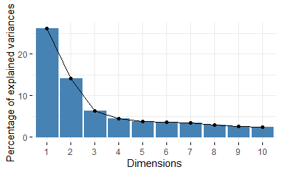

```r
xwt$weight = 1 / as.numeric(tab[xwt$sampleGroup])
pcaMouse = dudi.pca(as.data.frame(t(Biobase::exprs(xwt))),
  row.w = xwt$weight,
  center = TRUE, scale = TRUE, nf = 2, scannf = FALSE)
fviz_eig(pcaMouse) + ggtitle("")
```

> Screeplot from the weighted PCA of the Hiiragi data. The drop after the second eigenvalue suggests that a two-dimensional PCA is appropriate.

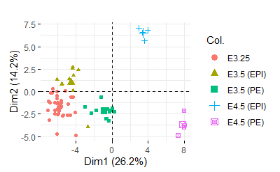

```r
fviz_pca_ind(pcaMouse, geom = "point", col.ind = xwt$sampleGroup) +
  ggtitle("") + coord_fixed()
```

> Output from weighted PCA on the Hiiragi data. The samples are colored according to their groups.
- Note that from tab data -> group are represented unequally
  - function `dudi.pca()` from ade4 package has row.w= argument to enter weights
    - output of this result is seen in the above screeplot + PCA plot

**Excercises**<sup>Return</sup>

#### 7.1

- Can decompose a matrix X with n row x p column rank 1

$$\begin{equation*}
{\bf X} =
\begin{pmatrix}
x_{11} & x_{12} &... & x_{1p}\\
x_{21} & x_{22} &... & x_{2p}\\
\vdots & \vdots &\vdots & \vdots \\
x_{n1} & x_{n2} &... & x_{np}
\end{pmatrix}
= \begin{pmatrix}
u_{11} \\ u_{21} \\
\vdots \\
u_{n1} \\
\end{pmatrix}
\times
\begin{pmatrix}
v_{11} & v_{21} & \cdots & v_{p1}
\end{pmatrix}
\end{equation*}$$

- 7.1a) If matrix X has no rows and no columns which are all zeros, then is this decomposition unique?
  - No, several candidates for vectors u & v
- 7.1b) Generate a rank-one matrix: Start by taking a vector of length 15 with values from 2 to 30 in increments of 2, and a vector of length 4 with values 3,6,9,12, take their ‘product’
  - Why do we have to take t(v)? -> from SVD formula SVD=USV^t where U is made from columns of AA^t, and V is made of corresponding rows by A^tA (in other words, column V^t matches columns of U via eigenvalue calcs (? - need to check))

```r
u = seq(2, 30, by = 2)
v = seq(3, 12, by = 3)
X1 = u %*% t(v)
X1
```

```
      [,1] [,2] [,3] [,4]
 [1,]    6   12   18   24
 [2,]   12   24   36   48
 [3,]   18   36   54   72
 [4,]   24   48   72   96
 [5,]   30   60   90  120
 [6,]   36   72  108  144
 [7,]   42   84  126  168
 [8,]   48   96  144  192
 [9,]   54  108  162  216
[10,]   60  120  180  240
[11,]   66  132  198  264
[12,]   72  144  216  288
[13,]   78  156  234  312
[14,]   84  168  252  336
[15,]   90  180  270  360
```

```r
X1.1 <- prcomp(X1)
svd(X1)$d #shows one relevant singular value >0 so rank 1
```

```
[1] 1.157238e+03 1.137458e-13 1.862094e-14 2.391251e-29
```

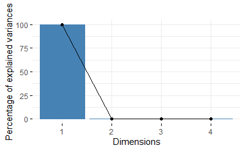

```r
# check eigenvalues/singular value
fviz_screeplot(X1.1) + ggtitle("")
```

- 7.1c) Now we add some noise in the form a matrix we call Materr so we have an “approximately rank-one” matrix.
  - Visualize X using ggplot.

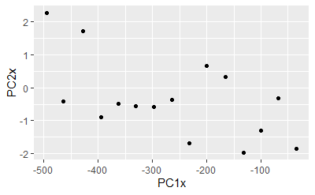

```r
Materr = matrix(rnorm(60,1),nrow=15,ncol=4)
X = X1+Materr
Xc <- svd(X)
#Plot PC1 & 2
Xcc <- tibble(PC1x = Xc$u[,1] * Xc$d[1], PC2x = Xc$u[,2] * Xc$d[2])
ggplot(Xcc, aes(x=PC1x, y=PC2x)) + geom_point()
```

- 7.1d) Redo the same analyses with a rank 2 matrix.

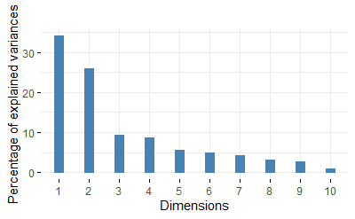

```r
#using above athletes data
fviz_eig(pca.ath, geom="bar", bar_width=0.3) + ggtitle("") #visualize rank 2
```

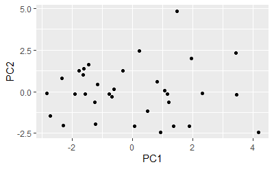

```r
pca.ath_1 <- tibble(PC1=pca.ath$li[,1], PC2=pca.ath$li[,2])
ggplot(pca.ath_1, aes(x=PC1, y=PC2)) + geom_point()
```

#### 7.2

- 7.2A) Create a first a matrix of highly correlated bivariate data such as that shown in Figure 7.35.
  - Hint: Use the function `mvrnorm()`.
  - Check the rank of the matrix by looking at its singular values.

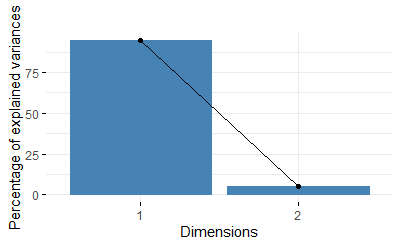

```r
mu1 = 1; mu2 = 2; s1=2.5; s2=0.8; rho=0.9;
sigma = matrix(c(s1^2, s1*s2*rho, s1*s2*rho, s2^2),2)
sim2d = data.frame(MASS::mvrnorm(50, mu = c(mu1,mu2), Sigma = sigma))
sim2d_1 <- prcomp(sim2d, scale=T)
fviz_screeplot(sim2d_1) + ggtitle("") #or svd(scale(sim2d))$d
```

- 7.2B) Perform a PCA and show the rotated principal component axes.

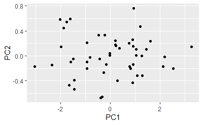

```r
sim2d_2 <- tibble(PC1=sim2d_1$x[,1], PC2=sim2d_1$x[,2])
ggplot(sim2d_2, aes(x=PC1, y=PC2)) + geom_point()
```

### Exercise 7.3

- Part (A) in Figure 7.35 shows a very elongated plotting region, why? What happens if you do not use the coord_fixed() option and have a square plotting zone? Why can this be misleading?
- Where is figure 7.35??
  - But based on ?coord_fixed()

> A fixed scale coordinate system forces a specified ratio between the physical representation of data units on the axes. The ratio represents the number of units on the y-axis equivalent to one unit on the x-axis. The default, ratio = 1, ensures that one unit on the x-axis is the same length as one unit on the y-axis. Ratios higher than one make units on the y axis longer than units on the x-axis, and vice versa. This is similar to MASS::eqscplot(), but it works for all types of graphics.
- Maintains aspect ratio

### Excercise 7.4

- Let’s revisit the Hiiragi data and compare the weighted and unweighted approaches.

*7.4a Make a correlation circle for the unweighted Hiiragi data xwt. Which genes have the best projections on the first principal plane (best approximation)?

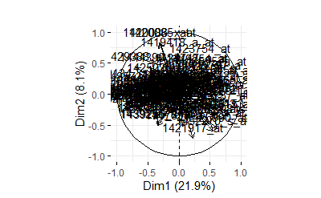

```r
pcaUW = dudi.pca(as.data.frame(t(Biobase::exprs(xwt))),
  center = TRUE, scale = TRUE, nf = 2, scannf = FALSE)
fviz_pca_var(pcaUW, col.circle="black") + ggtitle("")
```

- 7.4b Make a biplot showing the labels of the extreme gene-variables that explain most of the variance in the first plane. Add the the sample-points.

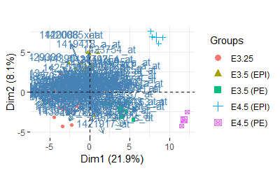

```r
fviz_pca_biplot(pcaUW, label="var", habillage = xwt$sampleGroup)  +
  coord_fixed() + ggtitle("")
```

**Miscellaneous**<sup>Return</sup>

*Run* = *Ctrl+Shift+Enter*  
*Insert Chunk* =*Ctrl+Alt+I*  
*Preview*=*Ctrl+Shift+K*

> [Unsupervised learning](https://www.mathworks.com/discovery/unsupervised-learning.html) is a type of machine learning algorithm used to draw inferences from datasets consisting of input data without labeled responses.

> [Supervised learning](https://www.mathworks.com/discovery/supervised-learning.html?s_tid=srchtitle) is a type of machine learning algorithm that uses a known dataset (called the training dataset) to make predictions. The training dataset includes input data and response values. From it, the supervised learning algorithm seeks to build a model that can make predictions of the response values for a new dataset. Using larger training datasets and optimizing model hyperparamamters can often increase the model’s predictive power and ensure that it can generalize well for new datasets. A test dataset is often used to validate the model.
- Discretization
  - Take continous functions/variables & transform into discrete functions/variables
  - 1st step in many types of analysis b/c discrete data easier to analyze
  - Theory
    - Process of discretization
      - Analyze continous values for variables
      - Divide into segments
      - Group into bins
        - Need to know how to select for #bins & how wide bins should be
  - Certain amount of error introducted per discretization
    - goal is to minimize error when choosing #bins & width
    - soluton: increase #intervals for division of function/variable
      - problem: increase intervals = less discretization
      - “what is min# intervals that can be used to divide to get ~accurate results”
  - Types
    - Statistic variable discretization = Discretize one variable at a time (most common)
    - Dynamic variable discretization = discrete all variables simultaneously. Need to keep track of independent interactiosn between variables
    - Unsupervised discretization algorithms = simplest algorithms, specify one parameter (#intervals to use or how many values per interval)
    - Supervised discretization algorithms = don’t specify #bins, based on entropy and purity calculations